# Replication of Study 3 in Artful Paltering: The Risks and Rewards of Using Truthful Statements to Mislead Others by Rogers, Zeckhauser, Gino, Norton, & Schweitzer (2017, Journal of Personality and Social Psychology)

Kayla Good (kagood@stanford.edu)

December 13, 2019

## Introduction

### Links

Github Project Repository: https://github.com/psych251/rogers2017

Preregistration link: https://osf.io/bt2rq

Original paper: https://github.com/psych251/rogers2017/blob/master/original_paper/Rogers_et_al_2017.pdf

Link to paradigm: https://stanforduniversity.qualtrics.com/jfe/form/SV_8iX8T8N6pXtSpmt

### Justification

In my research, I am primarily interested in exploring how different linguistic devices and forms of conversational implicature influence children’s and adults’ interpretations and evaluations of messages in a variety of domains, including the domains of achievement, preventative health, and nutrition. Recently, I developed a specific interest in how adults and children evaluate paltering, or the act of making statements that, while technically true, lead others to draw false conclusions. In the present replication project, I will replicate Study 3 of Rogers et al. (2017), which aimed to compare adults’ evaluations of the ethicality of paltering with their evaluations of honesty and another form of deception (lying by commission, or making false statements).

### Study Description

In Study 3, Rogers et al. (2017) asked adults to imagine that they were engaged in a negotiation and that their negotiation partner had either been honest, paltered, or lied by commission. I aimed to replicate the finding that adults evaluate partners who palter or lie by commission as equally unethical and untrustworthy (compared to honest partners) and report an equally low likelihood of entering into a subsequent negotiation with either partner (again, compared to honest partners, for whom they report a higher likelihood of agreeing to another negotiation).

### Challenges

Because I was relatively new to R and Github at the beginning of this project, one of the primary challenges involved my gaining the required knowledge and skills necessary for handling data and carrying out data analyses. However, I was confident that, with the skills we were learning in class as well as my having a strong background in STATA (and perhaps more importantly, experience with using Google to troubleshoot issues in STATA), that this would be an appropriately difficult challenge. From a data collection standpoint, I thought it would be challenging to ensure that the sample size is not affected substantially by exclusions due to failed attention checks; however, by being thoughtful about survey design and crafting a clear MTurk HIT description, I thought this issue could be minimized. Finally, I thought it might be a slight challenge to stay within budget, given the relatively high compensation rate used in the original study. However, I tried my best to use the same payment ($0.50 per participant) in order to maintain as much consistency with the original study as possible.

## Methods

### Power Analysis

Since effect sizes were not reported in the original paper, I calcuated the effect size for the analysis of interest using the condition means and standard deviations reported in Table 2 (Rogers et al., 2017) under the heading “Unethical Buyer.” (These means and standard deviations pertained specifically to the index indicating the extent to which participants found their trading partner [the “Buyer”] unethical.) The condition means and standard deviations for the ratings of the unethicality of the Buyer were specifically chosen because the key analysis of interest (further described in its own section later in this report) was the contrast (represented by a standardized beta coefficient and its corresponding p-value) indicating the difference between the paltering condition and the lying condition in participants’ ratings of the unethicality of the Buyer.

Condition means, variances, and sizes (n) were entered into WebPower’s effect size calculator for a fixed-effects, omnibus, one-way ANOVA. The resulting effect size was f = 0.2526, which is equivalent to Cohen’s d = 0.5052.

Using an effect size of f = 0.2526, the sample size needed to achieve 80% power was calculated via G*Power. The calculated sample size was 156 participants. This is remarkably close to the sample size used in the original study (where N = 160). Given that running this study with 156 participants already exceeded the funds allotted to this project, the goal for the present replication was to to recruit 156 participants. (While additional participants could have been recruited in order to achieve greater power, this was not feasible within the budget constraints of the present project.)

### Planned Sample

The original study was carried out with 160 participants (who were paid $0.50 each) on Amazon Mechanical Turk. Participants (N = 156, as determined by a power analysis) in the present replication were recruited in the same manner. Only adults (ages 18 and older) living in the United States were eligible to participate.

In the original study, participants who did not pass two initial attention check items (which comprised the first part of the survey and occurred prior to condition assignment) were directed to the end of the survey (it is unclear whether they received payment). Because class policy specifies that payment of participants is not contingent on their performance or completion of all survey questions, I planned to pay participants who began the survey but failed the initial attention check items; however, consistent with the original study, I planned to redirect these participants to the end of the survey immediately after attention check failure. Therefore, they would not be assigned to condition and would not be included in the final sample. (In the original study, while 160 were recruited, 5 failed the attention check, leaving a total of 155 participants.)

I expected that the demographics of the sample recruited for replication would be extremely similar to that of the sample recruited for the original study (with perhaps some differences due to chance). The original sample was 39% female and had a mean age of 30 years (SD = 8.96 years).

### Materials

Participants who passed two attention check items (described in the “Procedures” section below) were instructed to consider the following scenario, which did not differ across conditions:

> "You are the Executive Vice President of Pearl Investments, a holding company that specializes in real estate investments. You are in charge of negotiating the sale of a large piece of property located in Hamilton, a mid-sized town at the outskirts of a large metropolitan area.

> "How much a potential buyer will pay for the Hamilton property depends on a number of factors, including the planned use for the property. For example, your experts have estimated that if the land were developed for commercial use (e.g., a set of office buildings), the land might be worth 1.5 to 2 times as much as if it were developed for residential use (e.g., apartment buildings).

> "While property value would be maximized if the land were developed for commercial use, there is probably no interest for the property among commercial developers. The reason is that the zoning laws in Hamilton do not allow for commercial development of the property. While there has been some talk among local politicians of allowing commercial development in Hamilton over the last few years, no action has been taken. As a result, Hamilton has fallen off the radar for commercial developers.

> "Estate One, a premier real estate company in the region, has just sent word that they are interested in the Hamilton property. Your best estimate is that Estate One will develop the property for the construction of luxury condominiums (that is what they do with virtually all of their properties). On the call, the CEO of Estate One sounded extremely enthusiastic about the prospect of purchasing the Hamilton property.

> "You have decided that you will meet with the CEO of Estate One and try to negotiate a deal for the sale of the Hamilton property.

> “Here is what you know about Estate One: They are a mid-sized real estate company and they invest primarily in residential properties. The CEO of Estate One has been with the company since its founding twenty years ago and is known to have an eye for opportunity and for maximizing value potential in every deal. The CEO is also known to be extremely well connected politically, and is linked to knowledge brokers at all levels of state and local government. Estate One is not a competitor of yours.”

Following this scenario, participants were presented with information about the negotiation, which differed by condition.

In the paltering condition, participants read:

> “During your meeting with Estate One to negotiate, you asked the following question: Do you plan to develop the property for residential use? You received the following answer: ‘I have only ever developed properties for residential use before.’”

In the lying by commission condition, participants read:

> “During your meeting with Estate One to negotiate, you asked the following question: Do you plan to develop the property for residential use? You received the following answer: ‘Yes, I intend to develop the property for residential use.’”

In the honesty condition, participants read:

> “During your meeting with Estate One to negotiate, you asked the following question: Do you plan to develop the property for residential use? You received the following answer: ‘No, I intend to develop the property for commercial use.’”

In all conditions, participants were then presented with the following information:

> “You later discovered that, at the time of negotiations, the buyer knew that the property would soon be zoned for commercial development, thus making the value of the property higher.”

### Procedure

As in the original study, participants were directed to a Qualtrics survey, where they were first shown two attention check items. The first item consisted of a photo of an object that had to be correctly identified; this prevented bots from completing the survey. The second item consisted of instructions (quoted below) that participants had to read:

> “Recent research on decision making shows that choices are affected by context. Differences in how people feel, their previous knowledge and experience, and their environment can affect choices. To help us understand how people make decisions, we are interested in information about you. Specifically, we are interested in whether you actually take the time to read the directions; if not, some results may not tell us very much about decision making in the real world. To show that you have read the instructions, please ignore the question below about how you are feeling and instead check only the”none of the above" option as your answer. Thank you very much."

Following these instructions (but prior to condition assignment), participants were provided with a list of several emotions and had to select the last option (“None of the above”) in order to be included in the rest of the survey. Otherwise, they were directed to the end of the survey and were given instructions on how to receive payment.

Following the attention check items, participants were given the following instructions:

> “Your task in this study is to read a short scenario. You will be asked to imagine yourself in the situation described and then answer a few questions about it. Please read the scenario as carefully as possible.”

They were then presented with the main scenario quoted in the “Materials” section above. This scenario asked participants to imagine that they have to sell a large piece of real estate property, which will vary in value depending on whether the buyer intends to develop it for commercial or residential purposes. They were then told that they would be negotiating with a potential buyer. Participants were then randomly assigned to one of three conditions, in which the buyer is either honest about their intention for the property, palters, or lies by commission (see “Materials” above for the exact wording used in each condition).

After learning that the buyer was either honest or deceptive, participants were then asked to provide ratings (on 7-point Likert scales) of the buyer’s ethicality. Specifically, they were asked, “To what extent do you think the answer the Buyer gave you was…” and then had to rate (on three separate scales) the extent to which they found the Buyer’s answer was “unethical,” “dishonest,” and “immoral.” Participants were also asked, “To what extent do you think the Buyer is…” and had to rate the extent to which they found the Buyer to be “unethical,” “dishonest,” and “immoral.”

Participants were then asked to rate the extent to which they found the Buyer’s answer “creative,” “innovative,” or “original.”

Participants were also asked to rate the likelihood of their engaging in a future negotiation with the Buyer, which they rated on a 7-point Likert scale ranging from “Not likely at all” (1) to “Very likely” (7). Finally, they were asked to imagine that they had to negotiate with the Buyer again and were asked to rate their trust in the Buyer on a 7-point Likert scale ranging from “Not at all” (1) to “Very much” (7).

Following the primary dependent measures, participants were asked for demographic information, including their gender and age.

### Analysis Plan

#### Exclusion Criteria

Per the original study, participants were excluded if they failed either (or both) of the initial two attention check items. There were no other exclusion criteria.

#### Key Analysis of Interest

The key analysis of interest is the contrast representing the difference between the paltering condition and the lying condition in participants’ ratings of the unethicality of the Buyer. This contrast is represented by a standardized beta coefficient (and its corresponding p-value), which will be extracted from a a simple standardized linear regression examining the effect of condition (paltering, lying by commission, or honesty) on participants’ ratings of the unethicality of the Buyer. (Please note that this “unethicality rating” is an average of participants’ ratings on three items assessing the extent to which they believe the Buyer is “unethical,” “dishonest,” and “immoral”. This procedure was used in the original study, which referred to this average as “ethicality index”.)

The contrast respresented by the aforementioned standardized beta coefficient (and its corresponding p-value) was chosen as the key analysis of interest primarily because it tests a key hypothesis (and finding) of the original study (which is also a key claim made in the paper as a whole), namely, that individuals will evaluate someone who palters as negatively as someone who lies by commission in a negotiation context. If the p-value corresponding to this contrast is non-significant (p > .05), then this will be considered a successful replication of this finding, as this will indicate that participants rated negotiation partners who engaged in paltering and negotiation partners who lied by commission as equally unethical. This, in turn, will lend further support to the claim that individuals evaluate palterers (who make statements that, while intended to mislead, are technically true) as severely as those who lie by commission (who make statements that are untruthful).

Simple standardized linear regressions were also used in the original study, with contrasts between conditions (represented by standardized beta coefficients and their corresponding p-values) used to indicate differences (or a lack thereof). By employing a condition contrast within a simple standardized linear regression model as my key analysis of interest, I was able to directly compare my findings with those of the original authors.

As an additional note, while an ordinal regression might be considered more appropriate for data comprised of Likert scale ratings, it is common practice to treat such ratings as continuous (rather than ordinal) variables and enter them into a regression model accordingly. A simple linear regression, conducted for each ethicality index, the trust measure, as well as the likelihood of future negotiation measure, allowed me to determine the extent to which participants’ ratings for each of these measures differed depending on whether the Buyer was honest, paltered, or lied by commission.

#### Other Planned Analyses

In addition to the simple standardized linear regression model that contains the key analysis of interest, I planned to run three simple linear regressions to assess the effect of condition on participants’ ratings of the unethicality of the Buyer’s answer (which, like the Buyer unethicality rating, is also in the form of an “ethicality index” representing an average across three items assessing the extent to which they believe the Buyer is “unethical,” “dishonest,” and “immoral”), their trust in the Buyer, and their likelihood of engaging in a future negotiation with the Buyer.

### Differences from Original Study

There were no forseeable differences in the sample, with the exception of those due to chance, as I used the same recruitment pool utilized by the original authors (i.e., MTurk workers). The survey was conducted via the same survey platform used in the original study (Qualtrics).

In addition, I did not collect demographic data on ethnicity, student status, and whether English is their first language. While these questions were asked of participants in the original study, the authors reported in their paper that these were not analyzed. Therefore, in the interest of keeping the survey as brief as possible, I chose to exclude these measures from the replication. I did not anticipate that this will affect the results of the replication, as these measures came at the end of the survey and would therefore have not had an effect on participants’ responses to the key DVs of interest.

In addition, while participants were asked to rate the extent to which they found the Buyer’s answer “creative,” “innovative,” or “original,” the effect of condition on these ratings were not analyzed. The original paper did not report analyses on these ratings; however, I chose to include them in the procedure because they preceded key measures assessing trust and likelihood of negotiating with the same Buyer again. It is possible that having to consider aspects of the Buyer’s answer, such as its “creativity,” may have influenced responses on these other measures in the original study. Therefore, I decided to retain the measures in the survey (even though the results will not be analyzed) in order to maintain a faithful replication.

Finally, a 15-second delay on the appearance of the ‘next’ button (that allows participants to proceed through the survey) was added to the page containing the main scenario text. Although the original authors did not specify whether this was done in the original study (either in the paper or in their materials), I decided that adding a short delay (15 seconds) would be useful, particularly for discouraging inattentiveness to the text. One potential concern I had with adding the delay is that it might force anyone who reads the scenario quickly to consider this information longer than they normally would have – however, after timing myself reading the text several times, I found that it takes at least 30 seconds to read at a quick pace. Therefore, it seems unlikely that the delay could have generated meaningful differences between participants that could influence the results. (The delay should have also been short enough that it wasn’t frustrating to participants, who, with a longer delay, might have found it cumbersome to wait until they could proceed with the survey.)

### Methods Addendum (Post Data Collection)

#### Actual Sample

As planned, 156 participants were recruited and run via MTurk. 4 participants were excluded due to attention checks (which occurred prior to condition assignment), leaving 152 participants who were included in analyses. The demographics for this sample were very similar to those in the original study. Participants were 28% female with a mean age of 34 years (SD = 9.48 years). Participants were each paid 60 cents for their time; this payment was based on California minimum wage ($7.25/hour) and an estimated study duration of 5 minutes.

#### Differences from pre-data collection methods plan

There were no differences from the pre-data collection methods plan.

## Results

### Data preparation

Data were prepared following the analysis plan.

Participants’ ratings of the extent to which the Buyer’s answer, as well as the Buyer themselves, was “unethical,” “dishonest,” and “immoral” will be averaged to create two “ethicality indexes.” Participants’ ratings of how “creative,” “innovative,” and “original” the Buyer’s answer was will not be included in analyses.

```r
### Data Preparation

#### Load Relevant Libraries and Functions

library(knitr)
library(car)
library(lm.beta)
library(cowplot)
library(ggthemes)
library(mediation)
library(lavaan)
library(tidyverse)

#### Import data

replication_data <- read_csv("https://raw.githubusercontent.com/psych251/rogers2017/master/data/rogers2017_full_replication_data.csv") # reading in data from github

original_paper_data <- read_csv("https://raw.githubusercontent.com/psych251/rogers2017/master/data/Rogers2017Study3Means.csv") # reading in data from github

#### Data exclusion / filtering

clean_data <- replication_data %>%
  filter(ConsentYorN == "1", AC1 == "1", AC2 == "21") %>%  # filter out cases where the particpant did not consent or did not pass either attention check
  select(-c(1:17, 43:45, 50)) %>%
  slice(-1:-2) # removes unnecessary columns and rows

clean_data <- clean_data %>%
  mutate(Sub_ID = seq.int(nrow(clean_data))) %>%  # create subjectID column
  mutate(Condition = ifelse(!is.na(`PalterTiming_First Click`), "Palter",
                            ifelse(!is.na(`LieTiming_First Click`), "Lie",
                            ifelse(!is.na(`HonestyTiming_First Click`), "Honest", NA)))) %>%
# creates column with condition assignment
                            select(-c(contains("Timing")))  # this gets rid of the timing information, which we just needed to get condition assignment

clean_data$Sub_ID = factor(clean_data$Sub_ID) # converts SubID values to factor

#### Prepare data for analysis - create columns etc.

recoded_data <- clean_data %>%
   mutate(ConsentYorN = ifelse(ConsentYorN == 1, "YES", "NO"),
          Gender = ifelse(Gender == 1, "Male", "Female"),
          AC1 = ifelse(AC1 == 1, "Correct", "Incorrect"),
          AC2 = ifelse(AC2 == 21, "Correct", "Incorrect")) %>%  # recode variables
          mutate_at(vars(Condition), as.factor)

data_with_buyer_unethicality_index <- recoded_data %>%
    select(-contains("AnswerUnethical"), -FutureNegotiation, -BuyerTrust) %>%
    pivot_longer(cols = starts_with("BuyerUnethical"),
    names_to = "Buyer_Unethical_Question",
    names_prefix = "BuyerUnethical_",
    values_to = "BuyerUnethicalityRating",
    values_drop_na = TRUE) %>% # pivots ratings on three questions re: the unethicality of the Buyer themselves to long form
    mutate_at(vars(BuyerUnethicalityRating), as.numeric) %>% # converts data type of Likert ratings from character to numeric
    group_by(Sub_ID) %>%
    mutate(BuyerUnethicalityIndex = mean(BuyerUnethicalityRating, na.rm = TRUE)) # creates column with average across the three items re: the unethicality of the buyer's answer

data_with_ans_unethicality_index <- recoded_data %>%
    select(-contains("BuyerUnethical"), -FutureNegotiation, -BuyerTrust) %>%
    pivot_longer(cols = starts_with("AnswerUnethical"),
    names_to = "Ans_Unethical_Question",
    names_prefix = "AnswerUnethical_",
    values_to = "AnsUnethicalityRating",
    values_drop_na = TRUE) %>%  # pivots ratings on three questions re: the unethicality of the Buyer's answer to long form
    mutate_at(vars(AnsUnethicalityRating), as.numeric) %>% # converts data type of Likert ratings from character to numeric
    group_by(Sub_ID) %>%
    mutate(AnsUnethicalityIndex = mean(AnsUnethicalityRating, na.rm = TRUE)) # creates column with average across the three items re: the unethicality of the buyer's answer

buyer_trust_data <- recoded_data %>%
    select(-contains("AnswerUnethical"), -contains("BuyerUnethical"), -FutureNegotiation) %>%
    mutate_at(vars(BuyerTrust), as.numeric) # converts data type of Likert ratings from character to numeric

future_negotiation_data <- recoded_data %>%
    select(-contains("AnswerUnethical"), -contains("BuyerUnethical"), -BuyerTrust) %>%
    mutate_at(vars(FutureNegotiation), as.numeric) # converts data type of Likert ratings from character to numeric

buyer_ethicality_lm_data <- data_with_buyer_unethicality_index %>%
  filter(Buyer_Unethical_Question == 1)

ans_ethicality_lm_data <- data_with_ans_unethicality_index %>%
  filter(Ans_Unethical_Question == 1)
```

#### Sample Demographics

```r
# assessing demographics

gender_summary <- recoded_data %>%
  group_by(Gender) %>%
  summarise(n = length(Sub_ID)) %>%
              mutate(percentage = (n / sum(n))*100) # creates dataframe with percentage breakdown for gender of participants

gender_summary %>%
  kable() # generates table
```

| Gender | n | percentage |
| --- | --- | --- |
| Female | 43 | 28.28947 |
| Male | 109 | 71.71053 |

```r
age_summary <- recoded_data %>%
  mutate(Age = as.numeric(as.character(Age))) %>%
  summarise(mean_age = mean(Age),
            SD_age = sd(Age)) # creates dataframe with summary stats (mean and SD) for age of participants

age_summary %>%
  kable() # generates table
```

| mean_age | SD_age |
| --- | --- |
| 34.14474 | 9.480135 |

### Confirmatory analysis

The analyses were run as specified in the analysis plan. A simple linear regression was conducted in order to determine the effect of condition (if any) on participants’ ratings of the Buyer’s ethicality. Additional (non-key) linear regressions were also run to assess the effect of condition on participants’ ratings of the ethicality of the Buyer’s answer, their trust in the Buyer, and their likelihood of engaging in a future negotiation with the Buyer.

Below are simple linear regression models, which examine the relationship between condition and each of the primary DVs. I used the ‘lm.beta’ package to obtain standardized regression coefficients, which were reported in the original paper. I have included three regression models per DV, with each of the three models having a different condition as the reference (or comparison) group. This was necessary in order to examine all possible contrasts between conditions. Finally, prior to each model, I have provided a table with relevant descriptive statistics.

#### Buyer Ethicality Ratings

Below is a table containing descriptive statistics for Buyer unethicality.

```r
buyer_unethicality_condition_ns <- data_with_buyer_unethicality_index %>%
  filter(Buyer_Unethical_Question == 1) %>%
  group_by(Condition) %>%
  tally()

buyer_unethicality_means <- data_with_buyer_unethicality_index %>%
  filter(Buyer_Unethical_Question == 1) %>%
  group_by(Condition) %>%
  summarise(buyer_unethicality_mean = mean(BuyerUnethicalityIndex),
            buyer_unethicality_SD = sd(BuyerUnethicalityIndex)) %>%
  mutate(buyer_unethicality_ns = buyer_unethicality_condition_ns$n,
         buyer_unethicality_SE = buyer_unethicality_SD/sqrt(buyer_unethicality_ns)) # creates data frame with condition means, standard devations, standard errors, and Ns for the buyer unethicality index

buyer_unethicality_means %>%
  kable() # generates table
```

| Condition | buyer_unethicality_mean | buyer_unethicality_SD | buyer_unethicality_ns | buyer_unethicality_SE |
| --- | --- | --- | --- | --- |
| Honest | 3.659575 | 1.856558 | 47 | 0.2708069 |
| Lie | 4.610063 | 1.759875 | 53 | 0.2417375 |
| Palter | 4.653846 | 1.769952 | 52 | 0.2454482 |

Here is a summary of the effect of condition on ratings of the Buyer’s ethicality, with the “Lie” condition as the reference group:

```r
#  Buyer Ethicality - with Lie as reference group

buyer_ethicality_lm_data$Condition <- relevel(buyer_ethicality_lm_data$Condition, ref = "Lie") # changes reference group to Lie condition

buyer_unethicality_model_LieRef <- lm(BuyerUnethicalityIndex ~ Condition, data = buyer_ethicality_lm_data) # linear regression examining relationship between condition (explanatory variable) on ratings of the ethicality of the Buyer's answer (dependent variable), with Lie condition as reference group

buyer_unethicality_model_LieRef_nonstandardized <- summary(buyer_unethicality_model_LieRef) # summary of linear regression described immediately above

buyer_unethicality_model_LieRef_standardized <- summary(lm.beta(buyer_unethicality_model_LieRef)) # summary of linear regression described above with standardized beta coefficients

print(buyer_unethicality_model_LieRef_standardized)
```

```
##
## Call:
## lm(formula = BuyerUnethicalityIndex ~ Condition, data = buyer_ethicality_lm_data)
##
## Residuals:
##     Min      1Q  Median      3Q     Max
## -3.6538 -1.3262  0.3404  1.3899  2.6738
##
## Coefficients:
##                 Estimate Standardized Std. Error t value Pr(>|t|)
## (Intercept)      4.61006      0.00000    0.24638  18.711  < 2e-16 ***
## ConditionHonest -0.95049     -0.23979    0.35938  -2.645  0.00905 **
## ConditionPalter  0.04378      0.01134    0.35011   0.125  0.90065
## ---
## Signif. codes:  0 '***' 0.001 '**' 0.01 '*' 0.05 '.' 0.1 ' ' 1
##
## Residual standard error: 1.794 on 149 degrees of freedom
## Multiple R-squared:  0.06025,    Adjusted R-squared:  0.04764
## F-statistic: 4.777 on 2 and 149 DF,  p-value: 0.009757
```

Here is a summary of the effect of condition on ratings of the Buyer’s ethicality, with the “Honest” condition as the reference group:

```r
#  Buyer Ethicality - with Honest as reference group

buyer_ethicality_lm_data$Condition <- relevel(buyer_ethicality_lm_data$Condition, ref = "Honest") # changes reference group to Honest condition

buyer_unethicality_model_HonestRef <- lm(BuyerUnethicalityIndex ~ Condition, data = buyer_ethicality_lm_data) # linear regression examining relationship between condition (explanatory variable) on ratings of the ethicality of the Buyer's answer (dependent variable), with Honest condition as reference group

buyer_unethicality_model_HonestRef_nonstandardized <- summary(buyer_unethicality_model_HonestRef) # summary of linear regression described immediately above

buyer_unethicality_model_HonestRef_standardized <- summary(lm.beta(buyer_unethicality_model_HonestRef)) # summary of linear regression described above with standardized beta coefficients

print(buyer_unethicality_model_HonestRef_standardized)
```

```
##
## Call:
## lm(formula = BuyerUnethicalityIndex ~ Condition, data = buyer_ethicality_lm_data)
##
## Residuals:
##     Min      1Q  Median      3Q     Max
## -3.6538 -1.3262  0.3404  1.3899  2.6738
##
## Coefficients:
##                 Estimate Standardized Std. Error t value Pr(>|t|)
## (Intercept)       3.6596       0.0000     0.2616  13.987  < 2e-16 ***
## ConditionLie      0.9505       0.2473     0.3594   2.645  0.00905 **
## ConditionPalter   0.9943       0.2575     0.3610   2.754  0.00662 **
## ---
## Signif. codes:  0 '***' 0.001 '**' 0.01 '*' 0.05 '.' 0.1 ' ' 1
##
## Residual standard error: 1.794 on 149 degrees of freedom
## Multiple R-squared:  0.06025,    Adjusted R-squared:  0.04764
## F-statistic: 4.777 on 2 and 149 DF,  p-value: 0.009757
```

Here is a summary of the effect of condition on ratings of the Buyer’s ethicality, with the “Palter” condition as the reference group:

```r
#  Buyer Ethicality - with Palter as reference group

buyer_ethicality_lm_data$Condition <- relevel(buyer_ethicality_lm_data$Condition, ref = "Palter") # changes reference group to Palter condition

buyer_unethicality_model_PalterRef <- lm(BuyerUnethicalityIndex ~ Condition, data = buyer_ethicality_lm_data) # linear regression examining relationship between condition (explanatory variable) on ratings of the ethicality of the Buyer's answer (dependent variable), with Palter condition as reference group

buyer_unethicality_model_PalterRef_nonstandardized <- summary(buyer_unethicality_model_PalterRef) # summary of linear regression described immediately above

buyer_unethicality_model_PalterRef_standardized <- summary(lm.beta(buyer_unethicality_model_PalterRef)) # summary of linear regression described above with standardized beta coefficients

print(buyer_unethicality_model_PalterRef_standardized)
```

```
##
## Call:
## lm(formula = BuyerUnethicalityIndex ~ Condition, data = buyer_ethicality_lm_data)
##
## Residuals:
##     Min      1Q  Median      3Q     Max
## -3.6538 -1.3262  0.3404  1.3899  2.6738
##
## Coefficients:
##                 Estimate Standardized Std. Error t value Pr(>|t|)
## (Intercept)      4.65385      0.00000    0.24874  18.710  < 2e-16 ***
## ConditionHonest -0.99427     -0.25084    0.36100  -2.754  0.00662 **
## ConditionLie    -0.04378     -0.01139    0.35011  -0.125  0.90065
## ---
## Signif. codes:  0 '***' 0.001 '**' 0.01 '*' 0.05 '.' 0.1 ' ' 1
##
## Residual standard error: 1.794 on 149 degrees of freedom
## Multiple R-squared:  0.06025,    Adjusted R-squared:  0.04764
## F-statistic: 4.777 on 2 and 149 DF,  p-value: 0.009757
```

#### Ratings of the Ethicality of the Buyer’s Answer

Below is a table containing descriptive statistics for unethicality of the Buyer’s answer.

```r
answer_unethicality_condition_ns <- data_with_ans_unethicality_index %>%
  filter(Ans_Unethical_Question == 1) %>%
  group_by(Condition) %>%
  tally()

answer_unethicality_means <- data_with_ans_unethicality_index %>%
  filter(Ans_Unethical_Question == 1) %>%
  group_by(Condition) %>%
  summarise(answer_unethicality_mean = mean(AnsUnethicalityIndex),
            answer_unethicality_SD = sd(AnsUnethicalityIndex)) %>%
 mutate(answer_unethicality_ns = answer_unethicality_condition_ns$n,
        answer_unethicality_SE = answer_unethicality_SD/sqrt(answer_unethicality_ns))  # creates data frame with condition means, standard devations, standard errors, and Ns for the answer unethicality index

answer_unethicality_means %>%
  kable() # generates table
```

| Condition | answer_unethicality_mean | answer_unethicality_SD | answer_unethicality_ns | answer_unethicality_SE |
| --- | --- | --- | --- | --- |
| Honest | 3.397163 | 1.797258 | 47 | 0.2621570 |
| Lie | 4.691824 | 1.649720 | 53 | 0.2266065 |
| Palter | 4.269231 | 1.896032 | 52 | 0.2629324 |

Here is a summary of the effect of condition on ratings the ethicality of the Buyer’s answer, with the “Lie” condition as the reference group:

```r
#  Ethicality of Buyer's Answer - Lie as reference group

ans_ethicality_lm_data$Condition <- relevel(ans_ethicality_lm_data$Condition, ref = "Lie") # changes reference group to Lie condition

ans_unethicality_model_LieRef <- lm(AnsUnethicalityIndex ~ Condition, data = ans_ethicality_lm_data) # linear regression examining relationship between condition (explanatory variable) on ratings of the ethicality of the Buyer's answer (dependent variable), with Lie condition as reference group

ans_unethicality_model_LieRef_nonstandardized <- summary(ans_unethicality_model_LieRef) # summary of linear regression described immediately above

ans_unethicality_model_LieRef_standardized <- summary(lm.beta(ans_unethicality_model_LieRef)) # summary of linear regression described above with standardized beta coefficients

print(ans_unethicality_model_LieRef_standardized)
```

```
##
## Call:
## lm(formula = AnsUnethicalityIndex ~ Condition, data = ans_ethicality_lm_data)
##
## Residuals:
##     Min      1Q  Median      3Q     Max
## -3.6918 -1.2915  0.2695  1.3082  3.2695
##
## Coefficients:
##                 Estimate Standardized Std. Error t value Pr(>|t|)
## (Intercept)       4.6918       0.0000     0.2449  19.162  < 2e-16 ***
## ConditionHonest  -1.2947      -0.3246     0.3572  -3.625 0.000396 ***
## ConditionPalter  -0.4226      -0.1088     0.3479  -1.215 0.226451
## ---
## Signif. codes:  0 '***' 0.001 '**' 0.01 '*' 0.05 '.' 0.1 ' ' 1
##
## Residual standard error: 1.783 on 149 degrees of freedom
## Multiple R-squared:  0.08315,    Adjusted R-squared:  0.07084
## F-statistic: 6.756 on 2 and 149 DF,  p-value: 0.001554
```

Here is a summary of the effect of condition on ratings the ethicality of the Buyer’s answer, with the “Honest” condition as the reference group:

```r
#  Ethicality of Buyer's Answer - Honest as reference group

ans_ethicality_lm_data$Condition <- relevel(ans_ethicality_lm_data$Condition, ref = "Honest") # changes reference group to Honest condition

ans_unethicality_model_HonestRef <- lm(AnsUnethicalityIndex ~ Condition, data = ans_ethicality_lm_data) # linear regression examining relationship between condition (explanatory variable) on ratings of the ethicality of the Buyer's answer (dependent variable), with Honest condition as reference group

ans_unethicality_model_HonestRef_nonstandardized <- summary(ans_unethicality_model_HonestRef) # summary of linear regression described immediately above

ans_unethicality_model_HonestRef_standardized <- summary(lm.beta(ans_unethicality_model_HonestRef)) # summary of linear regression described above with standardized beta coefficients

print(ans_unethicality_model_HonestRef_standardized)
```

```
##
## Call:
## lm(formula = AnsUnethicalityIndex ~ Condition, data = ans_ethicality_lm_data)
##
## Residuals:
##     Min      1Q  Median      3Q     Max
## -3.6918 -1.2915  0.2695  1.3082  3.2695
##
## Coefficients:
##                 Estimate Standardized Std. Error t value Pr(>|t|)
## (Intercept)       3.3972       0.0000     0.2600  13.065  < 2e-16 ***
## ConditionLie      1.2947       0.3347     0.3572   3.625 0.000396 ***
## ConditionPalter   0.8721       0.2245     0.3588   2.431 0.016255 *
## ---
## Signif. codes:  0 '***' 0.001 '**' 0.01 '*' 0.05 '.' 0.1 ' ' 1
##
## Residual standard error: 1.783 on 149 degrees of freedom
## Multiple R-squared:  0.08315,    Adjusted R-squared:  0.07084
## F-statistic: 6.756 on 2 and 149 DF,  p-value: 0.001554
```

Here is a summary of the effect of condition on ratings the ethicality of the Buyer’s answer, with the “Palter” condition as the reference group:

```r
#  Ethicality of Buyer's Answer - Palter as reference group

ans_ethicality_lm_data$Condition <- relevel(ans_ethicality_lm_data$Condition, ref = "Palter") # changes reference group to Palter condition

ans_unethicality_model_PalterRef <- lm(AnsUnethicalityIndex ~ Condition, data = ans_ethicality_lm_data) # linear regression examining relationship between condition (explanatory variable) on ratings of the ethicality of the Buyer's answer (dependent variable), with Palter condition as reference group

ans_unethicality_model_PalterRef_nonstandardized <- summary(ans_unethicality_model_PalterRef) # summary of linear regression described immediately above

ans_unethicality_model_PalterRef_standardized <- summary(lm.beta(ans_unethicality_model_PalterRef)) # summary of linear regression described above with standardized beta coefficients

print(ans_unethicality_model_PalterRef_standardized)
```

```
##
## Call:
## lm(formula = AnsUnethicalityIndex ~ Condition, data = ans_ethicality_lm_data)
##
## Residuals:
##     Min      1Q  Median      3Q     Max
## -3.6918 -1.2915  0.2695  1.3082  3.2695
##
## Coefficients:
##                 Estimate Standardized Std. Error t value Pr(>|t|)
## (Intercept)       4.2692       0.0000     0.2472  17.271   <2e-16 ***
## ConditionHonest  -0.8721      -0.2187     0.3588  -2.431   0.0163 *
## ConditionLie      0.4226       0.1093     0.3479   1.215   0.2265
## ---
## Signif. codes:  0 '***' 0.001 '**' 0.01 '*' 0.05 '.' 0.1 ' ' 1
##
## Residual standard error: 1.783 on 149 degrees of freedom
## Multiple R-squared:  0.08315,    Adjusted R-squared:  0.07084
## F-statistic: 6.756 on 2 and 149 DF,  p-value: 0.001554
```

#### Ratings of Trust in Buyer

Below is a table containing descriptive statistics for trust in the Buyer.

```r
buyer_trust_data$Condition <- relevel(buyer_trust_data$Condition, ref = "Honest") # changes reference group to Honest condition

buyer_trust_condition_ns <- buyer_trust_data %>%
  group_by(Condition) %>%
  tally()

buyer_trust_means <- buyer_trust_data %>%
  group_by(Condition) %>%
  summarise(BuyerTrust_mean = mean(BuyerTrust),
           BuyerTrust_SD = sd(BuyerTrust)) %>%
 mutate(BuyerTrust_ns = buyer_trust_condition_ns$n,
        BuyerTrust_SE = BuyerTrust_SD/sqrt(BuyerTrust_ns)) # creates data frame with condition means, standard devations, standard errors, and Ns for Buyer trust

buyer_trust_means %>%
  kable() # generates table
```

| Condition | BuyerTrust_mean | BuyerTrust_SD | BuyerTrust_ns | BuyerTrust_SE |
| --- | --- | --- | --- | --- |
| Honest | 4.042553 | 1.910582 | 47 | 0.2786870 |
| Lie | 2.641509 | 1.582286 | 53 | 0.2173437 |
| Palter | 2.038461 | 1.267413 | 52 | 0.1757585 |

Here is a summary of the effect of condition on ratings of trust in the Buyer, with the “Lie” condition as the reference group:

```r
#  Trust in Buyer - with Lie as reference group

buyer_trust_data$Condition <- relevel(buyer_trust_data$Condition, ref = "Lie") # changes reference group to Lie condition

BuyerTrust_model_LieRef <- lm(BuyerTrust ~ Condition, data = buyer_trust_data) # linear regression examining relationship between condition (explanatory variable) on ratings of trust in the Buyer (dependent variable), with Lie condition as reference group

BuyerTrust_model_LieRef_nonstandardized <- summary(BuyerTrust_model_LieRef) # summary of linear regression described immediately above

BuyerTrust_model_LieRef_standardized <- summary(lm.beta(BuyerTrust_model_LieRef)) # summary of linear regression described above with standardized beta coefficients

print(BuyerTrust_model_LieRef_standardized)
```

```
##
## Call:
## lm(formula = BuyerTrust ~ Condition, data = buyer_trust_data)
##
## Residuals:
##     Min      1Q  Median      3Q     Max
## -3.0426 -1.0385 -0.0426  0.9615  3.9615
##
## Coefficients:
##                 Estimate Standardized Std. Error t value Pr(>|t|)
## (Intercept)       2.6415       0.0000     0.2194  12.041  < 2e-16 ***
## ConditionHonest   1.4010       0.3631     0.3200   4.378 2.24e-05 ***
## ConditionPalter  -0.6030      -0.1604     0.3117  -1.935   0.0549 .
## ---
## Signif. codes:  0 '***' 0.001 '**' 0.01 '*' 0.05 '.' 0.1 ' ' 1
##
## Residual standard error: 1.597 on 149 degrees of freedom
## Multiple R-squared:  0.2138, Adjusted R-squared:  0.2032
## F-statistic: 20.26 on 2 and 149 DF,  p-value: 1.65e-08
```

Here is a summary of the effect of condition on ratings of trust in the Buyer, with the “Honest” condition as the reference group:

```r
#  Trust in Buyer - with Honest as reference group

buyer_trust_data$Condition <- relevel(buyer_trust_data$Condition, ref = "Honest") # changes reference group to Honest condition

BuyerTrust_model_HonestRef <- lm(BuyerTrust ~ Condition, data = buyer_trust_data) # linear regression examining relationship between condition (explanatory variable) on ratings of trust in the Buyer (dependent variable), with Honest condition as reference group

BuyerTrust_model_HonestRef_nonstandardized <- summary(BuyerTrust_model_HonestRef) # summary of linear regression described immediately above

BuyerTrust_model_HonestRef_standardized <- summary(lm.beta(BuyerTrust_model_HonestRef)) # summary of linear regression described above with standardized beta coefficients

print(BuyerTrust_model_HonestRef_standardized)
```

```
##
## Call:
## lm(formula = BuyerTrust ~ Condition, data = buyer_trust_data)
##
## Residuals:
##     Min      1Q  Median      3Q     Max
## -3.0426 -1.0385 -0.0426  0.9615  3.9615
##
## Coefficients:
##                 Estimate Standardized Std. Error t value Pr(>|t|)
## (Intercept)       4.0426       0.0000     0.2330  17.354  < 2e-16 ***
## ConditionLie     -1.4010      -0.3744     0.3200  -4.378 2.24e-05 ***
## ConditionPalter  -2.0041      -0.5332     0.3214  -6.235 4.42e-09 ***
## ---
## Signif. codes:  0 '***' 0.001 '**' 0.01 '*' 0.05 '.' 0.1 ' ' 1
##
## Residual standard error: 1.597 on 149 degrees of freedom
## Multiple R-squared:  0.2138, Adjusted R-squared:  0.2032
## F-statistic: 20.26 on 2 and 149 DF,  p-value: 1.65e-08
```

Here is a summary of the effect of condition on ratings of trust in the Buyer, with the “Palter” condition as the reference group:

```r
#  Trust in Buyer - with Palter as reference group

buyer_trust_data$Condition <- relevel(buyer_trust_data$Condition, ref = "Palter") # changes reference group to Honest condition

BuyerTrust_model_PalterRef <- lm(BuyerTrust ~ Condition, data = buyer_trust_data) # linear regression examining relationship between condition (explanatory variable) on ratings of trust in the Buyer (dependent variable), with Palter condition as reference group

BuyerTrust_model_PalterRef_nonstandardized <- summary(BuyerTrust_model_PalterRef) # summary of linear regression described immediately above

BuyerTrust_model_PalterRef_standardized <- summary(lm.beta(BuyerTrust_model_PalterRef)) # summary of linear regression described above with standardized beta coefficients

print(BuyerTrust_model_PalterRef_standardized)
```

```
##
## Call:
## lm(formula = BuyerTrust ~ Condition, data = buyer_trust_data)
##
## Residuals:
##     Min      1Q  Median      3Q     Max
## -3.0426 -1.0385 -0.0426  0.9615  3.9615
##
## Coefficients:
##                 Estimate Standardized Std. Error t value Pr(>|t|)
## (Intercept)       2.0385       0.0000     0.2215   9.204 2.92e-16 ***
## ConditionHonest   2.0041       0.5194     0.3214   6.235 4.42e-09 ***
## ConditionLie      0.6030       0.1612     0.3117   1.935   0.0549 .
## ---
## Signif. codes:  0 '***' 0.001 '**' 0.01 '*' 0.05 '.' 0.1 ' ' 1
##
## Residual standard error: 1.597 on 149 degrees of freedom
## Multiple R-squared:  0.2138, Adjusted R-squared:  0.2032
## F-statistic: 20.26 on 2 and 149 DF,  p-value: 1.65e-08
```

#### Ratings of Likelihood of Engaging in Future Negotiation with Buyer

Below is a table containing descriptive statistics for likelihood of engaging in a future negotiation with the Buyer.

```r
future_negotiation_data$Condition <- relevel(future_negotiation_data$Condition, ref = "Honest") # changes reference group to Honest condition

future_negotiation_condition_ns <- future_negotiation_data %>%
  group_by(Condition) %>%
  tally()

future_negotiation_means <- future_negotiation_data %>%
  group_by(Condition) %>%
  summarise(FutureNegotiation_mean = mean(FutureNegotiation),
            FutureNegotiation_SD = sd(FutureNegotiation)) %>%
 mutate(FutureNegotiation_ns = future_negotiation_condition_ns$n,
        FutureNegotiation_SE = FutureNegotiation_SD/sqrt(FutureNegotiation_ns)) # creates data frame with condition means, standard devations, standard errors, and Ns for future negotiation

future_negotiation_means %>%
  kable() # generates table
```

| Condition | FutureNegotiation_mean | FutureNegotiation_SD | FutureNegotiation_ns | FutureNegotiation_SE |
| --- | --- | --- | --- | --- |
| Honest | 4.191489 | 1.541291 | 47 | 0.2248204 |
| Lie | 3.113208 | 1.489197 | 53 | 0.2045569 |
| Palter | 2.711539 | 1.785964 | 52 | 0.2476687 |

Here is a summary of the effect of condition on participants’ ratings of their likelihood of engaging in a future negotiation with the Buyer, with the “Lie” condition as the reference group:

```r
#  Future Negotiation - with Lie as reference group

future_negotiation_data$Condition <- relevel(future_negotiation_data$Condition, ref = "Lie") # changes reference group to Lie condition

Future_Negotiation_model_LieRef <- lm(FutureNegotiation ~ Condition, data = future_negotiation_data) # linear regression examining relationship between condition (explanatory variable) on ratings of trust in the Buyer (dependent variable), with Lie condition as reference group

Future_Negotiation_model_LieRef_nonstandardized <- summary(Future_Negotiation_model_LieRef) # summary of linear regression described immediately above

Future_Negotiation_model_LieRef_standardized <- summary(lm.beta(Future_Negotiation_model_LieRef)) # summary of linear regression described above with standardized beta coefficients

print(Future_Negotiation_model_LieRef_standardized)
```

```
##
## Call:
## lm(formula = FutureNegotiation ~ Condition, data = future_negotiation_data)
##
## Residuals:
##     Min      1Q  Median      3Q     Max
## -3.1915 -1.1915 -0.1132  0.8868  4.2885
##
## Coefficients:
##                 Estimate Standardized Std. Error t value Pr(>|t|)
## (Intercept)       3.1132       0.0000     0.2215  14.058  < 2e-16 ***
## ConditionHonest   1.0783       0.2914     0.3230   3.338  0.00107 **
## ConditionPalter  -0.4017      -0.1114     0.3147  -1.276  0.20379
## ---
## Signif. codes:  0 '***' 0.001 '**' 0.01 '*' 0.05 '.' 0.1 ' ' 1
##
## Residual standard error: 1.612 on 149 degrees of freedom
## Multiple R-squared:  0.1287, Adjusted R-squared:  0.117
## F-statistic:    11 on 2 and 149 DF,  p-value: 3.492e-05
```

Here is a summary of the effect of condition on participants’ ratings of their likelihood of engaging in a future negotiation with the Buyer, with the “Honest” condition as the reference group:

```r
# Future Negotiation - with Honest as reference group

future_negotiation_data$Condition <- relevel(future_negotiation_data$Condition, ref = "Honest") # changes reference group to Honest condition

Future_Negotiation_model_HonestRef <- lm(FutureNegotiation ~ Condition, data = future_negotiation_data) # linear regression examining relationship between condition (explanatory variable) on ratings of trust in the Buyer (dependent variable), with Honest condition as reference group

Future_Negotiation_model_HonestRef_nonstandardized <- summary(Future_Negotiation_model_HonestRef) # summary of linear regression described immediately above

Future_Negotiation_model_HonestRef_standardized <- summary(lm.beta(Future_Negotiation_model_HonestRef)) # summary of linear regression described above with standardized beta coefficients

print(Future_Negotiation_model_HonestRef_standardized)
```

```
##
## Call:
## lm(formula = FutureNegotiation ~ Condition, data = future_negotiation_data)
##
## Residuals:
##     Min      1Q  Median      3Q     Max
## -3.1915 -1.1915 -0.1132  0.8868  4.2885
##
## Coefficients:
##                 Estimate Standardized Std. Error t value Pr(>|t|)
## (Intercept)       4.1915       0.0000     0.2352  17.824  < 2e-16 ***
## ConditionLie     -1.0783      -0.3005     0.3230  -3.338  0.00107 **
## ConditionPalter  -1.4800      -0.4106     0.3245  -4.561 1.06e-05 ***
## ---
## Signif. codes:  0 '***' 0.001 '**' 0.01 '*' 0.05 '.' 0.1 ' ' 1
##
## Residual standard error: 1.612 on 149 degrees of freedom
## Multiple R-squared:  0.1287, Adjusted R-squared:  0.117
## F-statistic:    11 on 2 and 149 DF,  p-value: 3.492e-05
```

Here is a summary of the effect of condition on participants’ ratings of their likelihood of engaging in a future negotiation with the Buyer, with the “Palter” condition as the reference group:

```r
# Future Negotiation - with Palter as reference group

future_negotiation_data$Condition <- relevel(future_negotiation_data$Condition, ref = "Palter") # changes reference group to Palter condition

Future_Negotiation_model_PalterRef <- lm(FutureNegotiation ~ Condition, data = future_negotiation_data) # linear regression examining relationship between condition (explanatory variable) on ratings of trust in the Buyer (dependent variable), with Palter condition as reference group

Future_Negotiation_model_PalterRef_nonstandardized <- summary(Future_Negotiation_model_PalterRef) # summary of linear regression described immediately above

Future_Negotiation_model_PalterRef_standardized <- summary(lm.beta(Future_Negotiation_model_PalterRef)) # summary of linear regression described above with standardized beta coefficients

print(Future_Negotiation_model_PalterRef_standardized)
```

```
##
## Call:
## lm(formula = FutureNegotiation ~ Condition, data = future_negotiation_data)
##
## Residuals:
##     Min      1Q  Median      3Q     Max
## -3.1915 -1.1915 -0.1132  0.8868  4.2885
##
## Coefficients:
##                 Estimate Standardized Std. Error t value Pr(>|t|)
## (Intercept)       2.7115       0.0000     0.2236  12.128  < 2e-16 ***
## ConditionHonest   1.4800       0.4000     0.3245   4.561 1.06e-05 ***
## ConditionLie      0.4017       0.1119     0.3147   1.276    0.204
## ---
## Signif. codes:  0 '***' 0.001 '**' 0.01 '*' 0.05 '.' 0.1 ' ' 1
##
## Residual standard error: 1.612 on 149 degrees of freedom
## Multiple R-squared:  0.1287, Adjusted R-squared:  0.117
## F-statistic:    11 on 2 and 149 DF,  p-value: 3.492e-05
```

#### Side-by-Side Plots

To compare the findings from the present replication to the findings from the original study, side-by-side plots were generated.

```r
# plots based on replication data

mydata_buyer_unethicality_plot <- ggplot(buyer_unethicality_means, aes(x=Condition, y=buyer_unethicality_mean, fill=Condition)) +
  geom_bar(position = "dodge", stat="identity") +
  scale_fill_brewer(palette="Set1") +
  geom_errorbar(aes(ymin=buyer_unethicality_mean - buyer_unethicality_SE,
                    ymax=buyer_unethicality_mean + buyer_unethicality_SE), width = .2, position = position_dodge(.9)) +
  ylab("Buyer Unethicality (Mean Rating)") +
  scale_y_continuous(limits = c(0, 7), breaks=seq(0, 7, by = 1)) +
  theme_few() +
  theme(panel.border = element_blank(), axis.title.x = element_blank(), axis.title.y = element_blank()) # plot of condition means for ratings of Buyer ethicality

mydata_answer_unethicality_plot <- ggplot(answer_unethicality_means, aes(x=Condition, y=answer_unethicality_mean, fill=Condition)) +
  geom_bar(position = "dodge", stat="identity") +
  scale_fill_brewer(palette="Set1") +
  geom_errorbar(aes(ymin=answer_unethicality_mean - answer_unethicality_SE,
                    ymax=answer_unethicality_mean + answer_unethicality_SE), width = .2, position
                   = position_dodge(.9)) +
  ylab("Unethicality of Buyer's Answer (Mean Rating)") +
  scale_y_continuous(limits = c(0, 7), breaks=seq(0, 7, by = 1)) +
  theme_few() +
  theme(panel.border = element_blank(), axis.title.x = element_blank(),  axis.title.y = element_blank()) # plot of condition means for ratings of the ethicality of the Buyer's answer

mydata_buyer_trust_plot <- ggplot(buyer_trust_means, aes(x=Condition, y=BuyerTrust_mean, fill=Condition)) +
  geom_bar(position = "dodge", stat="identity") +
  scale_fill_brewer(palette="Set1") +
  geom_errorbar(aes(ymin=BuyerTrust_mean - BuyerTrust_SE, ymax=BuyerTrust_mean + BuyerTrust_SE),
                width = .2, position = position_dodge(.9)) +
  ylab("Trust in Buyer (Mean Rating)") +
  scale_y_continuous(limits = c(0, 7), breaks=seq(0, 7, by = 1)) +
  theme_few() +
  theme(panel.border = element_blank(), axis.title.x = element_blank(), axis.title.y = element_blank()) # plot of condition means for ratings of trust in the Buyer

mydata_future_negotiation_plot <- ggplot(future_negotiation_means, aes(x=Condition, y=FutureNegotiation_mean, fill=Condition)) +
  geom_bar(position = "dodge", stat="identity") +
  scale_fill_brewer(palette="Set1") +
  geom_errorbar(aes(ymin=FutureNegotiation_mean - FutureNegotiation_SE,
                    ymax=FutureNegotiation_mean + FutureNegotiation_SE), width = .2, position =
                    position_dodge(.9)) +
    ylab("Likelihood of Future Negotiation (Mean Rating)") +
  scale_y_continuous(limits = c(0, 7), breaks=seq(0, 7, by = 1)) +
  theme_few() +
  theme(panel.border = element_blank(), axis.title.x = element_blank(), axis.title.y = element_blank()) # plot of condition means for ratings of likelihood of engaging in a future negotiation with the Buyer
```

```r
# adding SEs to data frame containing original paper means and SDs

original_paper_data <- original_paper_data %>%
  mutate(Buyer_Unethicality_SE = Buyer_Unethicality_SD/sqrt(51),
         Answer_Unethicality_SE = Answer_Unethicality_SD/sqrt(51),
         BuyerTrust_SE = BuyerTrust_SD/sqrt(51),
         FutureNegotiation_SE = FutureNegotiation_SD/sqrt(51))
```

```r
# plots based on data from original study (taken from means and SDs reported in Table 2 of Rogers et al., 2017)

originaldata_buyer_unethicality_plot <- ggplot(original_paper_data, aes(x=Condition, y=Buyer_Unethicality_Mean, fill=Condition)) +
  geom_bar(position = "dodge", stat="identity") +
  scale_fill_brewer(palette="Set1") +
  geom_errorbar(aes(ymin=Buyer_Unethicality_Mean - Buyer_Unethicality_SE,
                    ymax=Buyer_Unethicality_Mean + Buyer_Unethicality_SE), width = .2, position =
                    position_dodge(.9)) +
    ylab("Buyer Unethicality (Mean Rating)") +
  scale_y_continuous(limits = c(0, 7), breaks=seq(0, 7, by = 1)) +
  theme_few() +
    theme(panel.border = element_blank(), axis.title.x = element_blank()) # plot of condition means for ratings of Buyer ethicality

originaldata_answer_unethicality_plot <- ggplot(original_paper_data, aes(x=Condition, y=Answer_Unethicality_Mean, fill=Condition)) +
  geom_bar(position = "dodge", stat="identity") +
  scale_fill_brewer(palette="Set1") +
  geom_errorbar(aes(ymin=Answer_Unethicality_Mean - Answer_Unethicality_SE,
                    ymax=Answer_Unethicality_Mean + Answer_Unethicality_SE), width = .2, position
                    = position_dodge(.9)) +
    ylab("Unethicality of Buyer's Answer (Mean Rating)") +
  scale_y_continuous(limits = c(0, 7), breaks=seq(0, 7, by = 1)) +
  theme_few() +
    theme(panel.border = element_blank(), axis.title.x = element_blank()) # plot of condition means for ratings of the ethicality of the Buyer's answer

originaldata_BuyerTrust_plot <- ggplot(original_paper_data, aes(x=Condition, y=BuyerTrust_mean, fill=Condition)) +
  geom_bar(position = "dodge", stat="identity") +
  scale_fill_brewer(palette="Set1") +
  geom_errorbar(aes(ymin=BuyerTrust_mean - BuyerTrust_SE, ymax=BuyerTrust_mean + BuyerTrust_SE),
                width = .2, position = position_dodge(.9)) +
    ylab("Trust in Buyer (Mean Rating)") +
  scale_y_continuous(limits = c(0, 7), breaks=seq(0, 7, by = 1)) +
  theme_few() +
    theme(panel.border = element_blank(), axis.title.x = element_blank()) # plot of condition means for ratings of trust in the Buyer

originaldata_FutureNegotiation_plot <- ggplot(original_paper_data, aes(x=Condition, y=FutureNegotiation_mean, fill=Condition)) +
  geom_bar(position = "dodge", stat="identity") +
  scale_fill_brewer(palette="Set1") +
  geom_errorbar(aes(ymin=FutureNegotiation_mean - FutureNegotiation_SE,
                    ymax=FutureNegotiation_mean + FutureNegotiation_SE), width = .2, position =
                    position_dodge(.9)) +
    ylab("Likelihood of Future Negotiation (Mean Rating)") +
  scale_y_continuous(limits = c(0, 7), breaks=seq(0, 7, by = 1)) +
  theme_few() +
    theme(panel.border = element_blank(), axis.title.x = element_blank()) # plot of condition means for ratings of likelihood of engaging in a future negotiation with the Buyer
```

Below are side-by-side plots showing the group means and SEs from the replication data (Plot “A”) and the group means and SEs from the original data (Plot “B”).

##### Ratings of the Unethicality of the Buyer

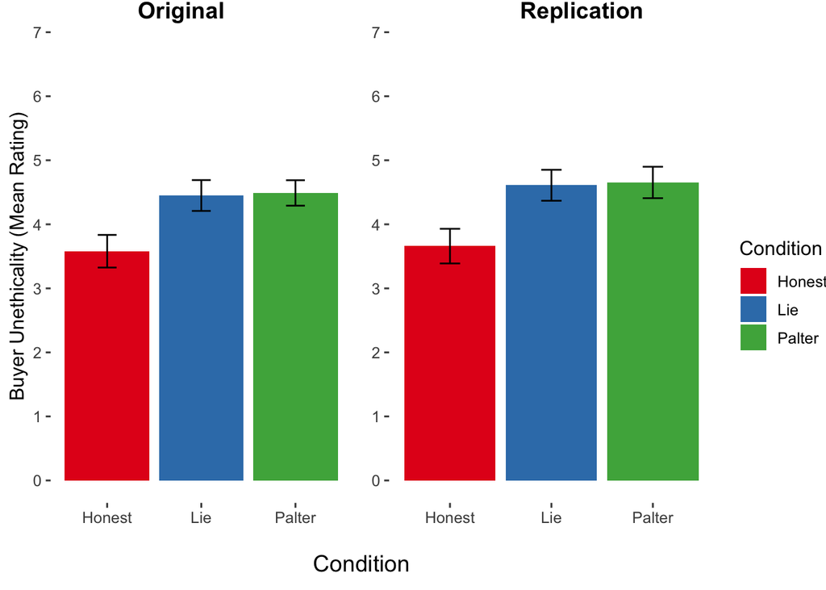

```r
# code for side-by-side plots
side_by_side_buyer_unethicality_plots <- plot_grid(
  originaldata_buyer_unethicality_plot + theme(legend.position = "none"),
  mydata_buyer_unethicality_plot + theme(legend.position = "none"),
  labels = c("Original", "Replication"),
  label_x = .25,
  hjust = -.55,
  vjust = 1.1)

buyer_plot_x_title <- ggdraw() + draw_label("Condition", fontface = "plain")
buyer_unethicality_legend <- get_legend(
  mydata_buyer_unethicality_plot +
    theme(legend.box.margin = margin(0, 0, 0, 12))
  )

side_by_side_buyer_unethicality_plots <- plot_grid(side_by_side_buyer_unethicality_plots, buyer_plot_x_title, ncol=1, rel_heights=c(1, 0.1))

side_by_side_buyer_unethicality_plots <- plot_grid(side_by_side_buyer_unethicality_plots, buyer_unethicality_legend, rel_widths = c(3, .425))

print(side_by_side_buyer_unethicality_plots)
```

##### Ratings of the Unethicality of the Buyer’s Answer

Please note that Plot “B” below does not have SE bars for the Honest condition because the group SD was not reported for this measure (see Table 2, Rogers et al., 2017).

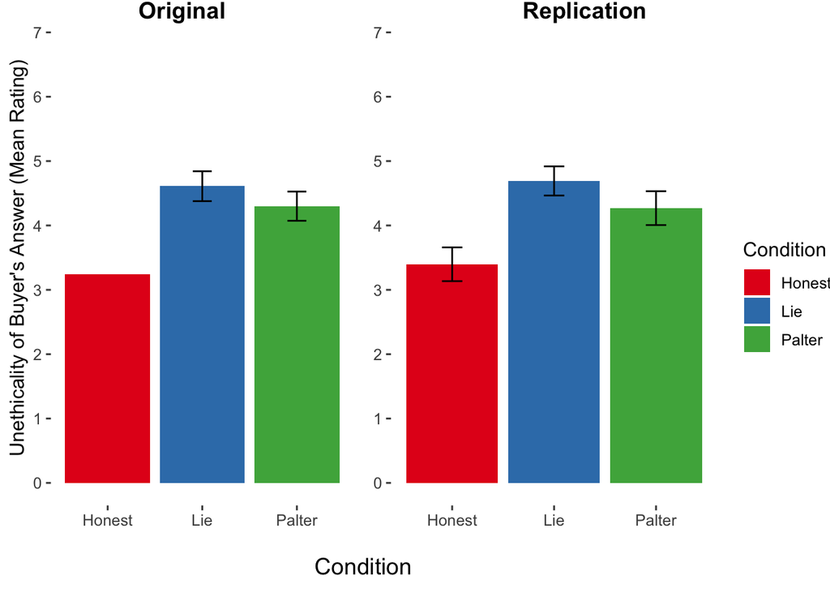

```r
side_by_side_answer_unethicality_plots <- plot_grid(
  originaldata_answer_unethicality_plot + theme(legend.position = "none"),
  mydata_answer_unethicality_plot + theme(legend.position = "none"),
  labels = c("Original", "Replication"),
  label_x = .25,
  hjust = -.55,
  vjust = 1.1)
answer_plot_x_title <- ggdraw() + draw_label("Condition", fontface = "plain")
answer_unethicality_legend <- get_legend(
  mydata_answer_unethicality_plot +
    theme(legend.box.margin = margin(0, 0, 0, 12))
  )

side_by_side_answer_unethicality_plots <- plot_grid(side_by_side_answer_unethicality_plots, answer_plot_x_title, ncol=1, rel_heights=c(1, 0.1))

side_by_side_answer_unethicality_plots <- plot_grid(side_by_side_answer_unethicality_plots, answer_unethicality_legend, rel_widths = c(3, .425))

print(side_by_side_answer_unethicality_plots)
```

##### Ratings of Trust in the Buyer

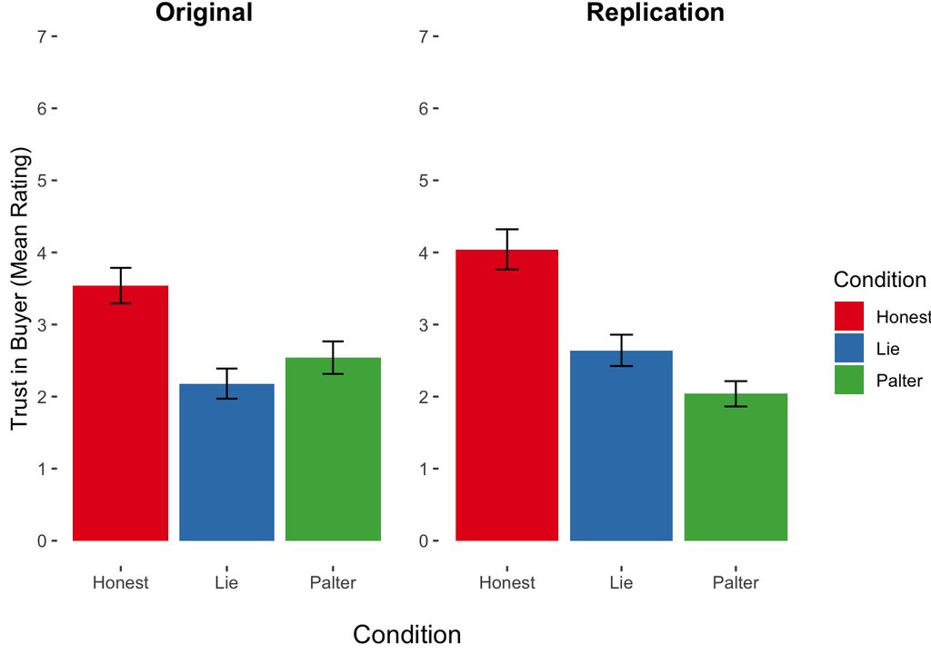

```r
side_by_side_BuyerTrust_plots <- plot_grid(
  originaldata_BuyerTrust_plot + theme(legend.position = "none"),
  mydata_buyer_trust_plot + theme(legend.position = "none"),
  labels = c("Original", "Replication"),
  label_x = .25,
  hjust = -.55,
  vjust = 1.1)

trust_plot_x_title <- ggdraw() + draw_label("Condition", fontface = "plain")
trust_legend <- get_legend(
  mydata_buyer_trust_plot +
    theme(legend.box.margin = margin(0, 0, 0, 12))
  )

side_by_side_BuyerTrust_plots <- plot_grid(side_by_side_BuyerTrust_plots, trust_plot_x_title, ncol=1, rel_heights=c(1, 0.1))

side_by_side_BuyerTrust_plots <- plot_grid(side_by_side_BuyerTrust_plots, trust_legend, rel_widths = c(3, .425))

print(side_by_side_BuyerTrust_plots)
```

##### Ratings of Likelihood of Future Negotiation

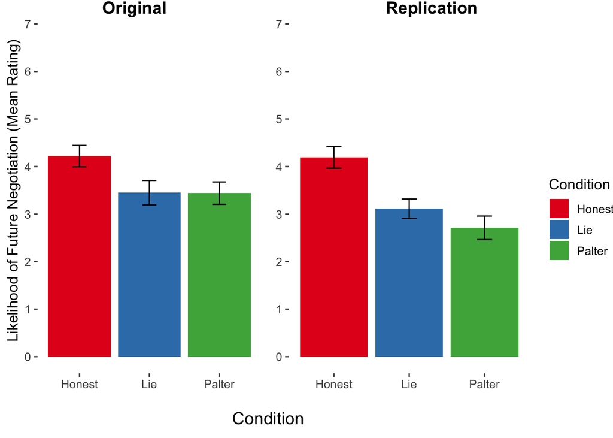

```r
side_by_side_FutureNegotiation_plots <- plot_grid(
  originaldata_FutureNegotiation_plot + theme(legend.position = "none"),
  mydata_future_negotiation_plot + theme(legend.position = "none"),
  labels = c("Original", "Replication"),
  label_x = .25,
  hjust = -.55,
  vjust = 1.1)

future_negotiation_plot_x_title <- ggdraw() + draw_label("Condition", fontface = "plain")
future_negotiation_legend <- get_legend(
  mydata_future_negotiation_plot +
    theme(legend.box.margin = margin(0, 0, 0, 12))
  )

side_by_side_FutureNegotiation_plots <- plot_grid(side_by_side_FutureNegotiation_plots, future_negotiation_plot_x_title, ncol=1, rel_heights=c(1, 0.1))

side_by_side_FutureNegotiation_plots <- plot_grid(side_by_side_FutureNegotiation_plots, future_negotiation_legend, rel_widths = c(3, .425))

print(side_by_side_FutureNegotiation_plots)
```

### Exploratory Analyses

Follow-up exploratory analyses were conducted to explore whether participants’ ratings of Buyer unethicality mediated the effect of condition on their 1) trust in the Buyer and 2) their likelihood of engaging in a future negotiation with the Buyer. While the original authors did not conduct these mediation analyses for Study 3 (the study targeted for replication in the present project), they did conduct a similar analysis in Study 1. In that study, the authors found that participants’ opted to mislead a negotiation partner more often when they had to choose between paltering or honesty (vs. when they had to choose between lying or honesty); a mediation analysis carried out using the Sobel-Goodman bootstrapping method revealed that this effect was mediated by participants’ perceived ethicality of the misleading option (either paltering or lying). (It is worth noting that, while the study I replicated did not find differences in participants’ ratings of the ethicality between the paltering and lying conditions, this is because participants in the present study were the *targets* of deception rather than the ones engaging in it themselves.)

For the present study, I decided to examine whether ratings of the unethicality of the Buyer mediated trust in the Buyer, as well as likelihood of future negotiation with the Buyer. The authors posit that those who palter or lie, compared to those who are honest, incur reputational costs (i.e., are perceived as more unethical). A negative reputation for being deceptive, in turn, has consequences for how much others trust these individuals as well as how much others are willing to negotiate with them in the future. This suggests that Buyer unethicality should, at least in part, mediate the effect of condition (whether the Buyer is honest, lies, or palters) on ratings of trust in the Buyer as well as likelihood of engaging in a future negotiation with them.

To conduct these mediation analyses, I first created a dataframe containing the measures of interest.

```r
# creating a dataframe for the purposes of mediation analysis, which includes the following measures: Buyer ethicality, trust in Buyer, and likelihood of future negotiation

mediation_data <- recoded_data %>%
    select(-contains("AnswerUnethical")) %>% # removes answer unethicality items, which will not be used in the exploratory mediation analyses
    pivot_longer(cols = starts_with("BuyerUnethical"),
    names_to = "Buyer_Unethical_Question",
    names_prefix = "BuyerUnethical_",
    values_to = "BuyerUnethicalityRating",
    values_drop_na = TRUE) %>% # pivots ratings on three questions re: the unethicality of the Buyer themselves to long form
    mutate_at(vars(BuyerUnethicalityRating), as.numeric) %>% # converts data type of Likert ratings from character to numeric
    group_by(Sub_ID) %>%
    mutate(BuyerUnethicalityIndex = mean(BuyerUnethicalityRating, na.rm = TRUE)) %>% # creates column with average across the three items re: the unethicality of the buyer's answer
    filter(Buyer_Unethical_Question == 1) %>% # removes repeated data
    select(-Buyer_Unethical_Question, -BuyerUnethicalityRating) %>%  # removes columns referencing individual items and ratings for Buyer unethicality, which are now unnecessary since mediation analyses will be carried out with the average across these items (the unethicality "index") for each participant
    mutate(Condition = ifelse(Condition == "Honest", 0,
                              ifelse(Condition == "Lie", 1,
                                     ifelse(Condition == "Palter", 2)))) # recodes condition using numeric values, as these are required by the mediate function that will be used for mediation analysis (see below)
```

I then used a “set seed” function, as all mediation analyses involve simulations (and would therefore vary slightly with each run unless “set seed” had been used).

```r
set.seed(123) # using set seed for reproducibility (since mediation analysis involves simulations)
```

Using the “mediate” function from the “mediation” package (Tingley et al., 2019), I first created a model assessing the extent to which ratings of Buyer unethicality mediate the effect of condition on ratings of trust in the Buyer. Please note that, for all models I have generated using the “mediate” function, I have used the default number of simulations (1000) and the nonparametric bootstrap type.

```r
# using mediation package to conduct mediation analysis for trust in Buyer

model_m <- lm(BuyerUnethicalityIndex ~ Condition, data = mediation_data) # regresses the mediator (Buyer unethicality) on the independent variable (Condition)

model_y_trust <- lm(BuyerTrust ~ BuyerUnethicalityIndex + Condition, data = mediation_data) # regresses the outcome variable (BuyerTrust) on both the mediator (Buyer unethicality) and the independent variable (Condition)

med_model_BuyerTrust <- mediate(model_m, model_y_trust, treat = "Condition", mediator = "BuyerUnethicalityIndex", boot = TRUE, boot.ci.type = "perc", sims = 1000) # generates mediation model
```

The summary below shows the summary of the mediation model for trust in the Buyer. (Please note that, in all summaries and plots pertaining to mediation analyses, “ACME” refers to the average causal mediation effect and “ADE” refers to the average direct effect.)

Both the indirect and direct effects are significant, suggesting partial mediation of Buyer unethicality on the relationship between condition and trust in the Buyer. This is consistent with the authors’ claim that at least part of the reason why participants trust the Buyer less when they palter or lie (vs. when they are honest) is due to their perceiving the Buyer as more unethical.

```r
print(summary(med_model_BuyerTrust)) # prints summary of mediation analysis
```

```
##
## Causal Mediation Analysis
##
## Nonparametric Bootstrap Confidence Intervals with the Percentile Method
##
##                Estimate 95% CI Lower 95% CI Upper p-value
## ACME            -0.2285      -0.4465        -0.06   0.006 **
## ADE             -0.7665      -1.0769        -0.45  <2e-16 ***
## Total Effect    -0.9950      -1.3373        -0.68  <2e-16 ***
## Prop. Mediated   0.2297       0.0674         0.44   0.006 **
## ---
## Signif. codes:  0 '***' 0.001 '**' 0.01 '*' 0.05 '.' 0.1 ' ' 1
##
## Sample Size Used: 152
##
##
## Simulations: 1000
```

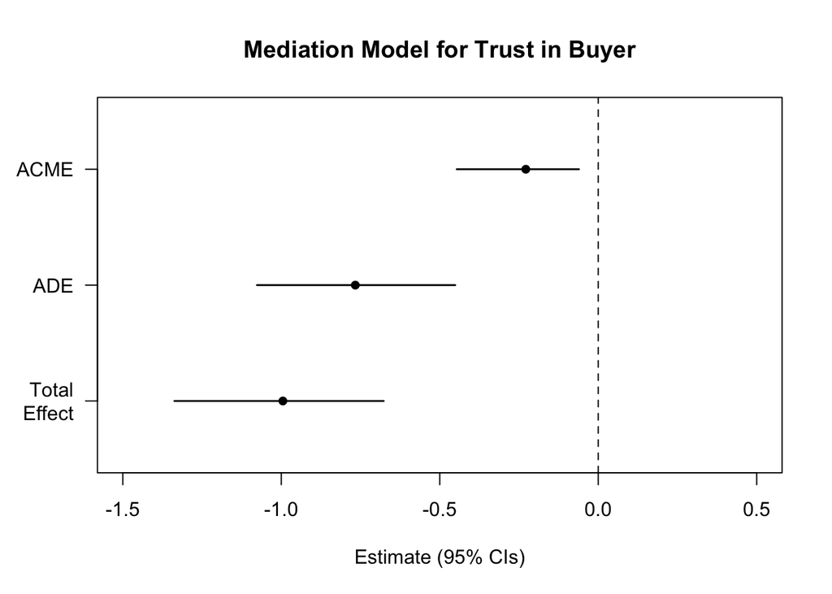

```r
print(plot(med_model_BuyerTrust,
           main = "Mediation Model for Trust in Buyer",
           xlim = c(-1.5, .5),
           xlab = "Estimate (95% CIs)")) # generates plot with point estimates, 95% CIs, and p-values for the ACME (average causal mediation effect), ADE (average direct effect), and total effect
```

I then created a model assessing the extent to which ratings of Buyer unethicality mediate the effect of condition on ratings of the likelihood of engaging in a future negotiation with the Buyer.

```r
# using mediation package to conduct mediation analysis for likelihood of future negotiation

model_y_future_negotiation <- lm(FutureNegotiation ~ BuyerUnethicalityIndex + Condition, data = mediation_data) # regresses the outcome variable (FutureNegotiation) on both the mediator (Buyer unethicality) and the independent variable (Condition)

med_model_FutureNegotiation <- mediate(model_m, model_y_future_negotiation, treat = "Condition", mediator = "BuyerUnethicalityIndex", boot = TRUE, boot.ci.type = "perc", sims = 1000) # generates mediation model
```

The summary below shows the summary of the mediation model for likelihood of engaging in a future negotiation with the Buyer.

As with the mediation model for trust in the Buyer, the indirect and direct effects are significant, suggesting partial mediation of Buyer unethicality on the relationship between condition and likelihood of engaging in a future negotiation with the Buyer. This is again consistent with the authors’ claim; that is, at least part of the reason why participants report being less likely to engage in a future negotiation with the Buyer when they palter or lie (vs. when they are honest) is due to their perceiving the Buyer as more unethical.

```r
print(summary(med_model_FutureNegotiation)) # prints summary of mediation analysis
```

```
##
## Causal Mediation Analysis
##
## Nonparametric Bootstrap Confidence Intervals with the Percentile Method
##
##                Estimate 95% CI Lower 95% CI Upper p-value
## ACME            -0.2065      -0.3955        -0.05   0.008 **
## ADE             -0.5275      -0.8159        -0.22   0.006 **
## Total Effect    -0.7340      -1.0288        -0.41  <2e-16 ***
## Prop. Mediated   0.2814       0.0877         0.57   0.008 **
## ---
## Signif. codes:  0 '***' 0.001 '**' 0.01 '*' 0.05 '.' 0.1 ' ' 1
##
## Sample Size Used: 152
##
##
## Simulations: 1000
```

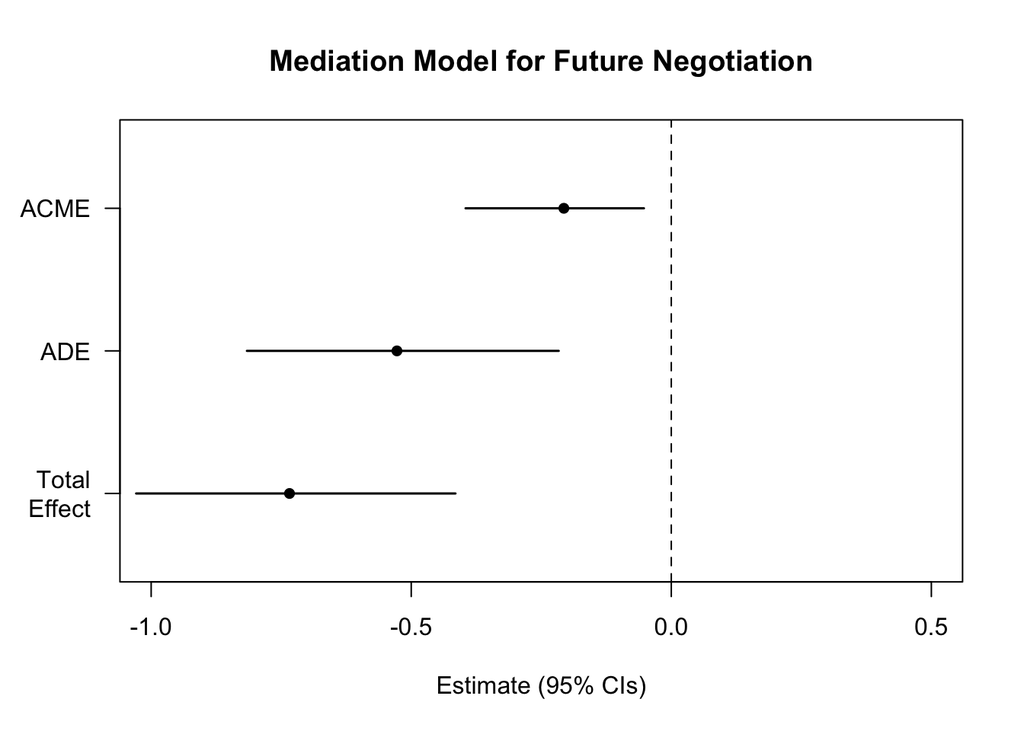

```r
print(plot(med_model_FutureNegotiation,
           main = "Mediation Model for Future Negotiation",
           xlim = c(-1, 0.5),
           xlab = "Estimate (95% CIs)")) # generates plot with point estimates, 95% CIs, and p-values for the ACME (average causal mediation effect), ADE (average direct effect), and total effect
```

Taken together, the mediation analyses reported above support the authors’ claim that the influence of whether the Buyer was honest, lied, or paltered on participants’ ratings of trust and likelihood of engaging in a future negotiation with the Buyer was due, in part, to perceptions of Buyer unethicality (which we know, from the confirmatory analyses, were higher in the deception conditions and lower in the honesty condition). This suggests that, when deception is discovered in a negotiation context, associated negative outcomes (i.e., lower trust and likelihood of future negotiation) are at least partially driven by negative reputational consequences (i.e., higher perceptions of unethicality).

#### Supplementary Exploratory Analyses

In conducting the mediation analyses reported above, I read the documentation for the “mediation” R package (Tingley et al., 2019), which stated that the “mediate” function is designed primarily to compare two conditions at a time (typically a “control” condition and a “treatment” condition). Since the present replication dealt with three conditions (honesty, paltering, and lying), I decided to run additional mediation models per the instructions in Section 3.3, entitled “Non-binary treatment variables”. This section describes how to run a mediation model for a specific contrast between two levels of a condition variable; by running a model for each possible contrast (or certain contrasts of interest), one can examine the mediation effect (if any) and compare this across different contrasts.

It is important to note that the mediation models below, like the ones described above, examine whether the effect of condition on trust in the Buyer and likelihood of engaging in a future negotiation with the Buyer is mediated by ratings of Buyer unethicality. However, these models take specific levels within the condition variable and examine each possible combination of them (honesty/lying, lying/paltering, and honesty/paltering).

Beginning with the effect of condition on trust in the Buyer, here is a summary of the mediation model containing the honesty/lying contrast:

```r
# using mediation package again, but this time including specific condition contrasts

med_model_BuyerTrust_honest_lie <- mediate(model_m, model_y_trust, treat = "Condition", mediator = "BuyerUnethicalityIndex", control.value = 0, treat.value = 1, boot = TRUE, sims = 1000) # gives contrast between 'honest' and 'lie' conditions

print(summary(med_model_BuyerTrust_honest_lie)) # prints summary of mediation analysis
```

```
##
## Causal Mediation Analysis
##
## Nonparametric Bootstrap Confidence Intervals with the Percentile Method
##
##                Estimate 95% CI Lower 95% CI Upper p-value
## ACME            -0.2285      -0.4194        -0.07   0.006 **
## ADE             -0.7665      -1.0744        -0.46  <2e-16 ***
## Total Effect    -0.9950      -1.3071        -0.66  <2e-16 ***
## Prop. Mediated   0.2297       0.0716         0.43   0.006 **
## ---
## Signif. codes:  0 '***' 0.001 '**' 0.01 '*' 0.05 '.' 0.1 ' ' 1
##
## Sample Size Used: 152
##
##
## Simulations: 1000
```

And here is a summary of the model containing the lying/paltering contrast:

```r
med_model_BuyerTrust_lie_palter <- mediate(model_m, model_y_trust, treat = "Condition", mediator = "BuyerUnethicalityIndex", control.value = 1, treat.value = 2, boot = TRUE, sims = 1000) # gives contrast between 'honest' and 'lie' conditions

print(summary(med_model_BuyerTrust_lie_palter)) # prints summary of mediation analysis
```

```
##
## Causal Mediation Analysis
##
## Nonparametric Bootstrap Confidence Intervals with the Percentile Method
##
##                Estimate 95% CI Lower 95% CI Upper p-value
## ACME            -0.2285      -0.4321        -0.06   0.008 **
## ADE             -0.7665      -1.0592        -0.45  <2e-16 ***
## Total Effect    -0.9950      -1.3128        -0.66  <2e-16 ***
## Prop. Mediated   0.2297       0.0632         0.44   0.008 **
## ---
## Signif. codes:  0 '***' 0.001 '**' 0.01 '*' 0.05 '.' 0.1 ' ' 1
##
## Sample Size Used: 152
##
##
## Simulations: 1000
```

And finally, here is a summary of the model containing the honesty/paltering contrast:

```r
med_model_BuyerTrust_honest_palter <- mediate(model_m, model_y_trust, treat = "Condition", mediator = "BuyerUnethicalityIndex", control.value = 0, treat.value = 2, boot = TRUE, sims = 1000) # gives contrast between 'honest' and 'lie' conditions

print(summary(med_model_BuyerTrust_honest_palter)) # prints summary of mediation analysis
```

```
##
## Causal Mediation Analysis
##
## Nonparametric Bootstrap Confidence Intervals with the Percentile Method
##
##                Estimate 95% CI Lower 95% CI Upper p-value
## ACME            -0.4570      -0.8484        -0.11   0.008 **
## ADE             -1.5330      -2.0912        -0.93  <2e-16 ***
## Total Effect    -1.9900      -2.6205        -1.31  <2e-16 ***
## Prop. Mediated   0.2297       0.0667         0.41   0.008 **
## ---
## Signif. codes:  0 '***' 0.001 '**' 0.01 '*' 0.05 '.' 0.1 ' ' 1
##
## Sample Size Used: 152
##
##
## Simulations: 1000
```

As you can see from the models above, they all show significant indirect and direct effects, confirming the findings from the original mediation model showing that Buyer unethicality partially mediates the effect of condition on trust in the Buyer.

The models below examine the same condition contrasts, but instead examine the effect of condition on participants’ reported likelihood of engaging in a future negotiation with the Buyer (and whether this is mediated by Buyer unethicality).

First, here is a summary of the mediation model containing the honesty/lying contrast:

```r
# using mediation package again, but this time including specific condition contrasts

med_model_FutureNegotiation_honest_lie <- mediate(model_m, model_y_future_negotiation, treat = "Condition", mediator = "BuyerUnethicalityIndex", control.value = 0, treat.value = 1, boot = TRUE, sims = 1000) # gives contrast between 'honest' and 'lie' conditions

print(summary(med_model_FutureNegotiation_honest_lie)) # prints summary of mediation analysis
```

```
##
## Causal Mediation Analysis
##
## Nonparametric Bootstrap Confidence Intervals with the Percentile Method
##
##                Estimate 95% CI Lower 95% CI Upper p-value
## ACME            -0.2065      -0.3902        -0.05   0.010 **
## ADE             -0.5275      -0.8094        -0.20   0.002 **
## Total Effect    -0.7340      -1.0374        -0.39  <2e-16 ***
## Prop. Mediated   0.2814       0.0774         0.56   0.010 **
## ---
## Signif. codes:  0 '***' 0.001 '**' 0.01 '*' 0.05 '.' 0.1 ' ' 1
##
## Sample Size Used: 152
##
##
## Simulations: 1000
```

And here is a summary of the model containing the lying/paltering contrast:

```r
med_model_FutureNegotiation_lie_palter <- mediate(model_m, model_y_future_negotiation, treat = "Condition", mediator = "BuyerUnethicalityIndex", control.value = 1, treat.value = 2, boot = TRUE, sims = 1000) # gives contrast between 'honest' and 'lie' conditions

print(summary(med_model_FutureNegotiation_lie_palter)) # prints summary of mediation analysis
```

```
##
## Causal Mediation Analysis
##
## Nonparametric Bootstrap Confidence Intervals with the Percentile Method
##
##                Estimate 95% CI Lower 95% CI Upper p-value
## ACME            -0.2065      -0.3942        -0.05   0.004 **
## ADE             -0.5275      -0.8027        -0.23  <2e-16 ***
## Total Effect    -0.7340      -1.0476        -0.40  <2e-16 ***
## Prop. Mediated   0.2814       0.0809         0.56   0.004 **
## ---
## Signif. codes:  0 '***' 0.001 '**' 0.01 '*' 0.05 '.' 0.1 ' ' 1
##
## Sample Size Used: 152
##
##
## Simulations: 1000
```

And finally, here is a summary of the model containing the honesty/paltering contrast:

```r
med_model_FutureNegotiation_honest_palter <- mediate(model_m, model_y_future_negotiation, treat = "Condition", mediator = "BuyerUnethicalityIndex", control.value = 0, treat.value = 2, boot = TRUE, sims = 1000) # gives contrast between 'honest' and 'lie' conditions

print(summary(med_model_FutureNegotiation_honest_palter)) # prints summary of mediation analysis
```

```
##
## Causal Mediation Analysis
##
## Nonparametric Bootstrap Confidence Intervals with the Percentile Method
##
##                Estimate 95% CI Lower 95% CI Upper p-value
## ACME            -0.4131      -0.7946        -0.10    0.01 **
## ADE             -1.0549      -1.6823        -0.49  <2e-16 ***
## Total Effect    -1.4680      -2.1344        -0.81  <2e-16 ***
## Prop. Mediated   0.2814       0.0787         0.55    0.01 **
## ---
## Signif. codes:  0 '***' 0.001 '**' 0.01 '*' 0.05 '.' 0.1 ' ' 1
##
## Sample Size Used: 152
##
##
## Simulations: 1000
```

Again, as you can see from these models, they all show significant indirect and direct effects, confirming the findings from the original mediation model showing that Buyer unethicality partially mediates the effect of condition on reported likelihood of engaging in a future negotiation with the Buyer.

Finally, as another supplementary exploratory analysis, I conducted the same mediation analyses using the “lavaan” package, which allowed me to examine the mediation effect without having to look at the separate condition contrasts.

Below is the mediation model for trust in the Buyer:

```r
# using lavaan package to conduct mediation analysis

buyer_trust_model <- '
              BuyerUnethicalityIndex ~ a*Condition
              BuyerTrust ~ b*BuyerUnethicalityIndex + c*Condition

             indirect := a*b
             direct   := c
             total    := c + (a*b)
' # generates regression models for mediation analysis

med_fit_buyer_trust <- sem(buyer_trust_model, data = mediation_data, se = "bootstrap") # generates mediation model

parameterEstimates(med_fit_buyer_trust, boot.ci.type = "bca.simple", level = 0.95, ci = TRUE, standardized = FALSE) %>%
  kable() # creates table summary of mediation analysis
```

| lhs | op | rhs | label | est | se | z | pvalue | ci.lower | ci.upper |
| --- | --- | --- | --- | --- | --- | --- | --- | --- | --- |
| BuyerUnethicalityIndex | ~ | Condition | a | 0.4891389 | 0.1796684 | 2.722454 | 0.0064799 | 0.1203666 | 0.8283826 |
| BuyerTrust | ~ | BuyerUnethicalityIndex | b | -0.4671971 | 0.0644216 | -7.252177 | 0.0000000 | -0.5775301 | -0.3200666 |
| BuyerTrust | ~ | Condition | c | -0.7664834 | 0.1468409 | -5.219822 | 0.0000002 | -1.0599350 | -0.4949997 |
| BuyerUnethicalityIndex | ~~ | BuyerUnethicalityIndex |  | 3.2004165 | 0.2691576 | 11.890492 | 0.0000000 | 2.7325887 | 3.8051791 |
| BuyerTrust | ~~ | BuyerTrust |  | 1.8377329 | 0.2099576 | 8.752877 | 0.0000000 | 1.5190520 | 2.3505743 |
| Condition | ~~ | Condition |  | 0.6502337 | 0.0000000 | NA | NA | 0.6502337 | 0.6502337 |
| indirect | := | a*b | indirect | -0.2285243 | 0.0947274 | -2.412441 | 0.0158461 | -0.4241693 | -0.0527248 |
| direct | := | c | direct | -0.7664834 | 0.1469145 | -5.217209 | 0.0000002 | -1.0599350 | -0.4949997 |
| total | := | c+(a*b) | total | -0.9950077 | 0.1602012 | -6.210987 | 0.0000000 | -1.3173946 | -0.6747708 |

And here is the model for likelihood of future negotiation:

```r
# using lavaan package to conduct mediation analysis

future_negotiation_model <- '
              BuyerUnethicalityIndex ~ a*Condition
              FutureNegotiation ~ b*BuyerUnethicalityIndex + c*Condition

             indirect := a*b
             direct   := c
             total    := c + (a*b)
' # generates regression models for mediation analysis

med_fit_future_negotiation <- sem(future_negotiation_model, data = mediation_data, se = "bootstrap") # generates mediation model

parameterEstimates(med_fit_future_negotiation, boot.ci.type = "bca.simple", level = 0.95, ci = TRUE, standardized = FALSE) %>%
  kable() # creates table summary of mediation analysis
```

| lhs | op | rhs | label | est | se | z | pvalue | ci.lower | ci.upper |
| --- | --- | --- | --- | --- | --- | --- | --- | --- | --- |
| BuyerUnethicalityIndex | ~ | Condition | a | 0.4891389 | 0.1861870 | 2.627138 | 0.0086106 | 0.0709272 | 0.8541939 |
| FutureNegotiation | ~ | BuyerUnethicalityIndex | b | -0.4222556 | 0.0682039 | -6.191073 | 0.0000000 | -0.5408759 | -0.2762808 |
| FutureNegotiation | ~ | Condition | c | -0.5274662 | 0.1582990 | -3.332087 | 0.0008620 | -0.8630855 | -0.2387629 |
| BuyerUnethicalityIndex | ~~ | BuyerUnethicalityIndex |  | 3.2004165 | 0.2617291 | 12.227974 | 0.0000000 | 2.7608397 | 3.7901068 |
| FutureNegotiation | ~~ | FutureNegotiation |  | 2.0031674 | 0.2675496 | 7.487089 | 0.0000000 | 1.5667581 | 2.6428327 |
| Condition | ~~ | Condition |  | 0.6502337 | 0.0000000 | NA | NA | 0.6502337 | 0.6502337 |
| indirect | := | a*b | indirect | -0.2065416 | 0.0875248 | -2.359806 | 0.0182845 | -0.3873570 | -0.0325074 |
| direct | := | c | direct | -0.5274662 | 0.1583784 | -3.330417 | 0.0008672 | -0.8630855 | -0.2387629 |
| total | := | c+(a*b) | total | -0.7340079 | 0.1677243 | -4.376277 | 0.0000121 | -1.0517792 | -0.4080371 |

Again, both of these models show significant direct and indirect effects, suggesting that Buyer unethicality partially mediates the effect of condition on 1) trust in the Buyer and 2) reported likelihood of engaging in a future negotiation with the Buyer.

## Discussion

### Summary of Replication Attempt

To conclude, the key finding that individuals evaluate those who palter and those who lie by commission as being equally unethical was successfully replicated. In the original study, the contrast between the paltering and lying conditions in simple linear regression assessing the effect of condition on ratings of the unethicality of the Buyer indicated a non-significant p-value (p = .91); this p-value was also non-significant in the present replication (p = .90). This finding not only demontrates that participants view those who palter and lie as being equally unethical, but it also provides indirect support for the original authors’ broader claim that judgments of those who palter give more weight to the intent to mislead rather than the truth value of the statement (which is reflected in palterers being judged as severely as those who outright lie).

### Commentary

Follow-up exploratory analysis provide support the original authors’ claim that, in a negotiation context, the negative reputational consequences of lying and paltering (i.e., being perceived as more unethical relative to those who are honest) are one reason why individuals trust liars and palterers less and report being less likely to engage in a future negotiation with them. Specifically, mediation analyses revealed that ratings of Buyer unethicality partially mediate the relationship between condition (honesty, lying, or paltering) and trust in the Buyer, as well as the relationship between condition and likelihood of engaging in a future negotiation with the Buyer. This suggests that the effect of whether one’s negotiation partner is deceptive or honest on one’s trust in that individual is driven, in part, by one’s perceptions of how unethical that individual is; the same can be said for one’s reported likelihood of engaging in a future negotiation with that individual.

These findings, along with the findings from the confirmatory analysis, highlight the risks of engaging in paltering as a negotiation strategy. While paltering might seem less unethical than lying by commission from a first-person perspective (i.e., when making decisions about how one should proceed in a negotiation; Study 1, Rogers et al., 2017), the key finding replicated in the present report suggests that, if one’s intent to mislead is discovered, one could be judged with the same severity as they would have been if they had lied. This has interesting implications for future work, which should examine how paltering is evaluated relative to lying in different contexts (e.g., in the moral domain).